# Forecasting Project

# Process my ARIMA model

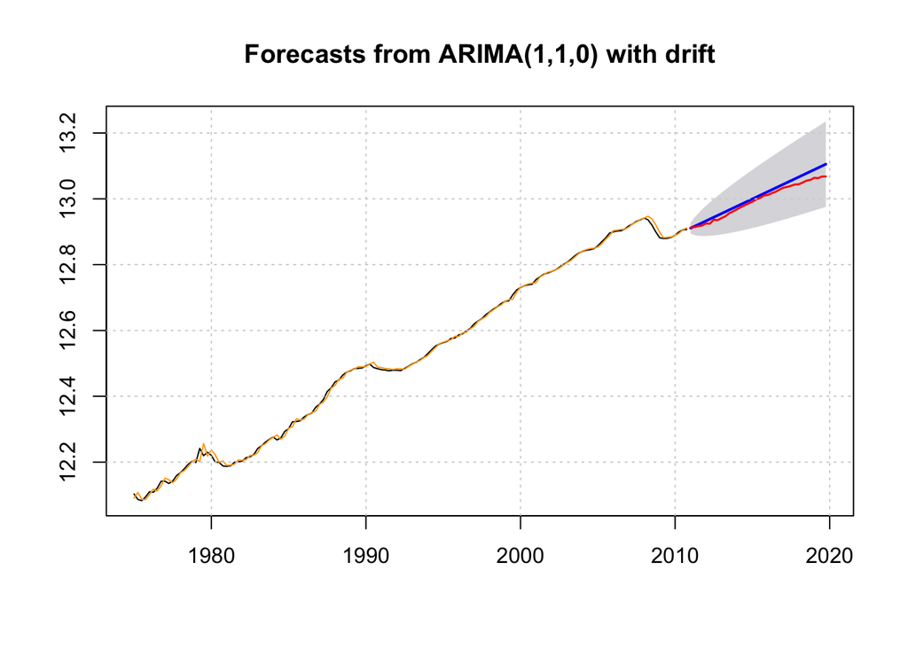

```r
# ARIMA(d=1) model, take first difference due to its non-stationarity
gdp.mod <- Arima(train.ts,order=c(1,1,0),include.constant = TRUE )

# forecast (95% confidence interval)
gdp.fcast <- forecast(gdp.mod,h=nvalid,level=95)
plot(gdp.fcast)
lines(gdp.fcast$fitted,col = 'orange')
lines(valid.ts, col='red', lwd = 1.5)
grid()
```

```r
print('ARIMA Model Performance')
```

```
## [1] "ARIMA Model Performance"
```

```r
print(accuracy(gdp.fcast,valid.ts))
```

```
##                         ME        RMSE         MAE          MPE       MAPE
## Training set  0.0001248983 0.008396047 0.005550093  0.001064754 0.04465924
## Test set     -0.0135331953 0.015989221 0.013637867 -0.103958830 0.10476942
##                   MASE        ACF1 Theil's U
## Training set 0.1907761 -0.09141661        NA
## Test set     0.4687811  0.77998871  3.042889
```

# Baseline Models

### auto.arima (Use BIC info to choose model, BIC is a larger penalty at longer time horizons)

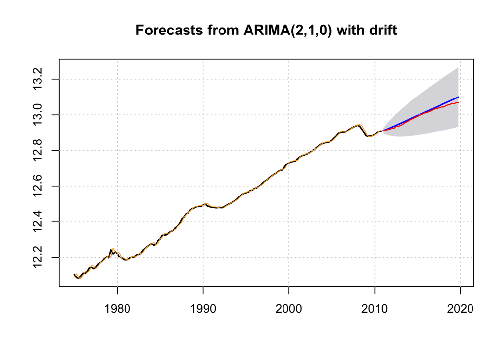

```r
gdp.mod.bic <- auto.arima(train.ts,d=1,ic="bic",seasonal=FALSE)

# forecast (95% confidence interval)
gdp.fcast.bic <- forecast(gdp.mod.bic,h=nvalid,level=95)
plot(gdp.fcast.bic,lwd=2)
lines(gdp.fcast.bic$fitted,col = 'orange')
lines(valid.ts,col='red',lwd = 1.5)
grid()
```

```r
print('auto.ARIMA Model Performance (BIC Selection)')
```

```
## [1] "auto.ARIMA Model Performance (BIC Selection)"
```

```r
print(accuracy(gdp.fcast.bic,valid.ts))
```

```
##                         ME        RMSE        MAE         MPE       MAPE
## Training set  0.0001853534 0.008135643 0.00541685  0.00154867 0.04357389
## Test set     -0.0100324809 0.012510718 0.01011065 -0.07705966 0.07766504
##                   MASE        ACF1 Theil's U
## Training set 0.1861961 -0.06371166        NA
## Test set     0.3475385  0.76951685  2.380413
```

```r
#DM Test
#one accepted forecasting system:ARIMA model(e1) VS a challeger(e2)
#I want to know if sqr(e2) < sqr(e1). If this is true, the new forecasting system connected to e2 would be beter.
#This suggests a null hypothesis sqr(e2) >= sqr(e1), and an alternative where sqr(e2) < sqr(e1).
#In R this would be dm.test(e2,e1,alternative=”less”)

print("Diebold/Mariano ARIMA versus auto.ARIMA (BIC Selection): alternative = less")
```

```
## [1] "Diebold/Mariano ARIMA versus auto.ARIMA (BIC Selection): alternative = less"
```

```r
print(dm.test(residuals(gdp.fcast.bic),residuals(gdp.fcast),alternative="less"))
```

```
##
##  Diebold-Mariano Test
##
## data:  residuals(gdp.fcast.bic)residuals(gdp.fcast)
## DM = -1.1488, Forecast horizon = 1, Loss function power = 2, p-value =
## 0.1263
## alternative hypothesis: less
```

P-value = 0.1263 in DM_test test, fail to reject the null at 5% level.

### Naive model

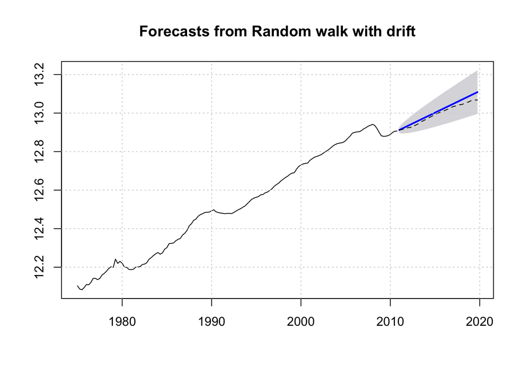

```r
# Find naive forecast
gdp.naive.drift <-  rwf(train.ts, h = nvalid, drift = TRUE, level = 95)

# plot the forecast in the validation period
plot(gdp.naive.drift)
lines(gdp.naive.drift$mean,col="blue",lwd=2)
lines(valid.ts,lty="dashed")
grid()
```

```r
print(accuracy(gdp.naive.drift,valid.ts))
```

```
##                         ME        RMSE         MAE           MPE       MAPE
## Training set -1.117982e-16 0.008601612 0.005950832  5.079912e-05 0.04779491
## Test set     -1.614529e-02 0.018500080 0.016181672 -1.240416e-01 0.12432329
##                   MASE      ACF1 Theil's U
## Training set 0.2045509 0.2274337        NA
## Test set     0.5562206 0.7868864  3.522051
```

```r
print("Diebold/Mariano ARIMA versus naive test: alternative = less")
```

```
## [1] "Diebold/Mariano ARIMA versus naive test: alternative = less"
```

```r
print(dm.test(residuals(gdp.naive.drift),residuals(gdp.fcast),alternative="less"))
```

```
##
##  Diebold-Mariano Test
##
## data:  residuals(gdp.naive.drift)residuals(gdp.fcast)
## DM = 0.74949, Forecast horizon = 1, Loss function power = 2, p-value =
## 0.7726
## alternative hypothesis: less
```

P-value = 0.7726 in DM_test test, fail to reject the null at 5% level.

### ETS

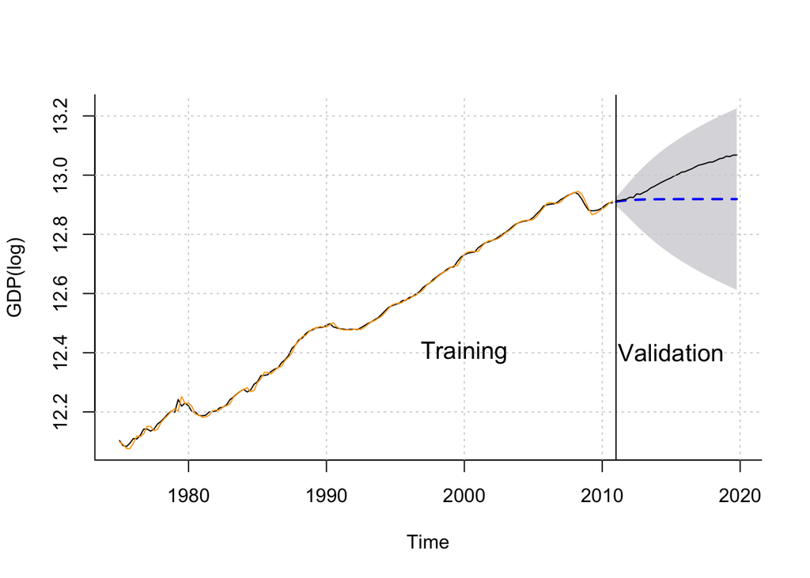

```r
#Level + Trend, Holts linear model, AAN (data is seasonally adjusted)
ses = ets(train.ts, model = 'AAN',opt.crit = 'mse') #let the model itself finds out the optimal parameter
ses.pred = forecast(ses,h = nvalid, level = 95)

#plot the forecasts, fitted value and valid data
plot(ses.pred, ylab = 'GDP(log)',xlab = 'Time',bty = 'l', main = '', flty=2)
lines(ses.pred$fitted, lwd=1,col="orange")
lines(valid.ts)
grid()
#add partition line and training/validation mark
ntrain = length(time(train.ts))
valid2x = 1975 + (0+ntrain)/4
lines(c(valid2x,valid2x),c(-40,120),lwd = 1, col = 'black')
text(2000,12.4,'Training',cex = 1.25)
text(2015,12.4,'Validation',cex = 1.25)
```

```r
#find out the accuracy of the model, check the performance
print('ETS Model Performance')
```

```
## [1] "ETS Model Performance"
```

```r
print(accuracy(ses.pred,valid.ts))
```

```
##                       ME        RMSE         MAE        MPE       MAPE
## Training set 0.001804693 0.008236889 0.005768882 0.01449766 0.04632868
## Test set     0.076581482 0.091284976 0.076581482 0.58783869 0.58783869
##                   MASE        ACF1 Theil's U
## Training set 0.1982967 -0.05584748        NA
## Test set     2.6323733  0.93448818  17.37309
```

```r
print("Diebold/Mariano ARIMA versus Holts linear model: alternative = less")
```

```
## [1] "Diebold/Mariano ARIMA versus Holts linear model: alternative = less"
```

```r
print(dm.test(residuals(ses.pred),residuals(gdp.fcast),alternative="less"))
```

```
##
##  Diebold-Mariano Test
##
## data:  residuals(ses.pred)residuals(gdp.fcast)
## DM = -0.399, Forecast horizon = 1, Loss function power = 2, p-value =
## 0.3452
## alternative hypothesis: less
```

P-value = 0.3452 in DM_test test, fail to reject the null at 5% level.

## RMSE Comparison

```r
paste('The RMSE for ARIMA (my model) is',accuracy(gdp.fcast,valid.ts)[2,2])
```

```
## [1] "The RMSE for ARIMA (my model) is 0.0159892211193598"
```

```r
paste('The RMSEs for three baseline models are:')
```

```
## [1] "The RMSEs for three baseline models are:"
```

```r
paste(accuracy(gdp.fcast.bic,valid.ts)[2,2],'(AUTO.ARIMA)')
```

```
## [1] "0.0125107184329662 (AUTO.ARIMA)"
```

```r
paste(accuracy(gdp.naive.drift,valid.ts)[2,2],'(Naive)')
```

```
## [1] "0.0185000800708339 (Naive)"
```

```r
paste(accuracy(ses.pred,valid.ts)[2,2],'(ETS)')
```

```
## [1] "0.0912849759841197 (ETS)"
```